# 1. Import the libraries, load dataset, print shape of data, visualize the images in dataset. (5 Marks)

# 4. Building CNN: (15 Marks)

a. Define layers.

b. Set optimizer and loss function. (Use Adam optimizer and categorical crossentropy.)

```python
from keras.models import Sequential
from keras.layers import Dense, Dropout, Flatten, Conv2D, MaxPool2D, GlobalMaxPooling2D
from keras.optimizers import RMSprop
from keras.preprocessing.image import ImageDataGenerator
from keras.optimizers import Adam

batch_size = None

model = Sequential()

model.add(Conv2D(filters = 32, kernel_size = (5,5),padding = 'Same',
                 activation ='relu', batch_input_shape = (batch_size,128, 128, 3)))


model.add(Conv2D(filters = 32, kernel_size = (5,5),padding = 'Same',
                 activation ='relu'))
model.add(MaxPool2D(pool_size=(2,2)))
model.add(Dropout(0.2))


model.add(Conv2D(filters = 64, kernel_size = (3,3),padding = 'Same',
                 activation ='relu'))
model.add(Conv2D(filters = 64, kernel_size = (3,3),padding = 'same',
                 activation ='relu'))
model.add(MaxPool2D(pool_size=(2,2), strides=(2,2)))
model.add(Dropout(0.3))

model.add(Conv2D(filters = 128, kernel_size = (3,3),padding = 'Same',
                 activation ='relu'))
model.add(Conv2D(filters = 128, kernel_size = (3,3),padding = 'Same',
                 activation ='relu'))
model.add(MaxPool2D(pool_size=(2,2), strides=(2,2)))
model.add(Dropout(0.4))



model.add(GlobalMaxPooling2D())
model.add(Dense(256, activation = "relu"))
model.add(Dropout(0.5))
model.add(Dense(12, activation = "softmax"))
model.summary()
```

```
Model: "sequential"
_________________________________________________________________
Layer (type)                 Output Shape              Param #
=================================================================
conv2d (Conv2D)              (None, 128, 128, 32)      2432
_________________________________________________________________
conv2d_1 (Conv2D)            (None, 128, 128, 32)      25632
_________________________________________________________________
max_pooling2d (MaxPooling2D) (None, 64, 64, 32)        0
_________________________________________________________________
dropout (Dropout)            (None, 64, 64, 32)        0
_________________________________________________________________
conv2d_2 (Conv2D)            (None, 64, 64, 64)        18496
_________________________________________________________________
conv2d_3 (Conv2D)            (None, 64, 64, 64)        36928
_________________________________________________________________
max_pooling2d_1 (MaxPooling2 (None, 32, 32, 64)        0
_________________________________________________________________
dropout_1 (Dropout)          (None, 32, 32, 64)        0
_________________________________________________________________
conv2d_4 (Conv2D)            (None, 32, 32, 128)       73856
_________________________________________________________________
conv2d_5 (Conv2D)            (None, 32, 32, 128)       147584
_________________________________________________________________
max_pooling2d_2 (MaxPooling2 (None, 16, 16, 128)       0
_________________________________________________________________
dropout_2 (Dropout)          (None, 16, 16, 128)       0
_________________________________________________________________
global_max_pooling2d (Global (None, 128)               0
_________________________________________________________________
dense (Dense)                (None, 256)               33024
_________________________________________________________________
dropout_3 (Dropout)          (None, 256)               0
_________________________________________________________________
dense_1 (Dense)              (None, 12)                3084
=================================================================
Total params: 341,036
Trainable params: 341,036
Non-trainable params: 0
_________________________________________________________________
```

```python
opt = Adam(lr=0.001)

optimizer = RMSprop(lr=0.001, rho=0.9, epsilon=1e-08, decay=0.0)
model.compile(optimizer = optimizer, loss = "categorical_crossentropy", metrics = ["accuracy"])
```

```python
model.fit(X_train, y_train, epochs = 50, validation_data = (X_val,y_val),batch_size = batch_size)
```

```
<tensorflow.python.keras.callbacks.History at 0x7eff30118198>
```

```python
score = model.evaluate(X_test, y_test, verbose=0, batch_size = 38)
print('Test loss:', score[0])
print('Test accuracy:', score[1])
```

```
Test loss: 0.3244847357273102
Test accuracy: 0.8876404762268066
```

call back Reduce learning rate when a metric has stopped improving.

Models often benefit from reducing the learning rate by a factor of 2-10 once learning stagnates. This callback monitors a quantity and if no improvement is seen for a 'patience' number of epochs, the learning rate is reduced

```python
from keras.callbacks import ReduceLROnPlateau

learning_rate_reduction = ReduceLROnPlateau(monitor='val_accuracy',
                                            patience=3,
                                            verbose=1,
                                            factor=0.5,
                                            min_lr=0.00001)
epochs = 30
batch_size = 38
```

```python
# Generate batches of tensor image data with real-time data augmentation.


datagen = ImageDataGenerator(
        featurewise_center=False,  # set input mean to 0 over the dataset
        samplewise_center=False,  # set each sample mean to 0
        featurewise_std_normalization=False,  # divide inputs by std of the dataset
        samplewise_std_normalization=False,  # divide each input by its std
        zca_whitening=False,  # apply ZCA whitening
        rotation_range=10,  # randomly rotate images in the range (degrees, 0 to 180)
        zoom_range = 0.1, # Randomly zoom image
        width_shift_range=0.1,  # randomly shift images horizontally (fraction of total width)
        height_shift_range=0.1,  # randomly shift images vertically (fraction of total height)
        horizontal_flip=False,  # randomly flip images
        vertical_flip=False)  # randomly flip images


datagen.fit(X_train)
```

```python
X_train, X_test, y_train, y_test
history = model.fit_generator(datagen.flow(X_train,y_train, batch_size=batch_size),
                              epochs = epochs, validation_data = (X_val,y_val),
                              verbose = 2, steps_per_epoch=X_train.shape[0] // batch_size
                              , callbacks=[learning_rate_reduction])
```

```
87/87 - 14s - loss: 0.3421 - accuracy: 0.8887 - val_loss: 0.4763 - val_accuracy: 0.8331
87/87 - 12s - loss: 0.3287 - accuracy: 0.8823 - val_loss: 0.3949 - val_accuracy: 0.8738
87/87 - 12s - loss: 0.3245 - accuracy: 0.8923 - val_loss: 0.3546 - val_accuracy: 0.8738
87/87 - 12s - loss: 0.2922 - accuracy: 0.8947 - val_loss: 0.3536 - val_accuracy: 0.8654
87/87 - 12s - loss: 0.3045 - accuracy: 0.9017 - val_loss: 0.2925 - val_accuracy: 0.8976
87/87 - 12s - loss: 0.2939 - accuracy: 0.9005 - val_loss: 0.3789 - val_accuracy: 0.8682
87/87 - 12s - loss: 0.3332 - accuracy: 0.9066 - val_loss: 0.4127 - val_accuracy: 0.8710
87/87 - 12s - loss: 0.3261 - accuracy: 0.8883 - val_loss: 0.5095 - val_accuracy: 0.8233

Epoch 00008: ReduceLROnPlateau reducing learning rate to 0.0005000000237487257.
87/87 - 12s - loss: 0.2145 - accuracy: 0.9273 - val_loss: 0.2818 - val_accuracy: 0.9046
87/87 - 12s - loss: 0.1914 - accuracy: 0.9337 - val_loss: 0.2374 - val_accuracy: 0.9130
87/87 - 12s - loss: 0.1690 - accuracy: 0.9431 - val_loss: 0.2230 - val_accuracy: 0.9158
87/87 - 12s - loss: 0.1730 - accuracy: 0.9334 - val_loss: 0.2797 - val_accuracy: 0.8962
87/87 - 12s - loss: 0.1775 - accuracy: 0.9358 - val_loss: 0.2748 - val_accuracy: 0.9088
87/87 - 12s - loss: 0.1685 - accuracy: 0.9428 - val_loss: 0.2633 - val_accuracy: 0.9130

Epoch 00014: ReduceLROnPlateau reducing learning rate to 0.0002500000118743628.
87/87 - 12s - loss: 0.1262 - accuracy: 0.9525 - val_loss: 0.2526 - val_accuracy: 0.9173
87/87 - 12s - loss: 0.1092 - accuracy: 0.9568 - val_loss: 0.2405 - val_accuracy: 0.9201
87/87 - 12s - loss: 0.1203 - accuracy: 0.9556 - val_loss: 0.2316 - val_accuracy: 0.9187
87/87 - 12s - loss: 0.1154 - accuracy: 0.9589 - val_loss: 0.2507 - val_accuracy: 0.9116
87/87 - 12s - loss: 0.1016 - accuracy: 0.9617 - val_loss: 0.2694 - val_accuracy: 0.9130

Epoch 00019: ReduceLROnPlateau reducing learning rate to 0.0001250000059371814.
87/87 - 12s - loss: 0.0928 - accuracy: 0.9674 - val_loss: 0.2467 - val_accuracy: 0.9215
87/87 - 12s - loss: 0.0870 - accuracy: 0.9699 - val_loss: 0.2416 - val_accuracy: 0.9243
87/87 - 12s - loss: 0.0883 - accuracy: 0.9693 - val_loss: 0.2771 - val_accuracy: 0.9102
87/87 - 12s - loss: 0.0954 - accuracy: 0.9696 - val_loss: 0.2399 - val_accuracy: 0.9257
87/87 - 12s - loss: 0.0869 - accuracy: 0.9696 - val_loss: 0.2622 - val_accuracy: 0.9116
87/87 - 12s - loss: 0.0815 - accuracy: 0.9693 - val_loss: 0.2820 - val_accuracy: 0.9201
87/87 - 12s - loss: 0.0886 - accuracy: 0.9741 - val_loss: 0.2635 - val_accuracy: 0.9257

Epoch 00026: ReduceLROnPlateau reducing learning rate to 6.25000029685907e-05.
87/87 - 12s - loss: 0.0792 - accuracy: 0.9732 - val_loss: 0.2634 - val_accuracy: 0.9187
87/87 - 12s - loss: 0.0734 - accuracy: 0.9726 - val_loss: 0.2605 - val_accuracy: 0.9187
87/87 - 12s - loss: 0.0739 - accuracy: 0.9741 - val_loss: 0.2542 - val_accuracy: 0.9201

Epoch 00029: ReduceLROnPlateau reducing learning rate to 3.125000148429535e-05.
87/87 - 12s - loss: 0.0675 - accuracy: 0.9744 - val_loss: 0.2589 - val_accuracy: 0.9215
```

```python
score = model.evaluate(X_test, y_test, verbose=0, batch_size = None)
print('Test loss:', score[0])
print('Test accuracy:', score[1])
```

```
Test loss: 0.2758660316467285
Test accuracy: 0.9129213690757751
```

The final accuracy of the model with data augmentation can be reached to 92% and loss is also decraesed.

# 5. Fit and evaluate model and print confusion matrix. (10 Marks)

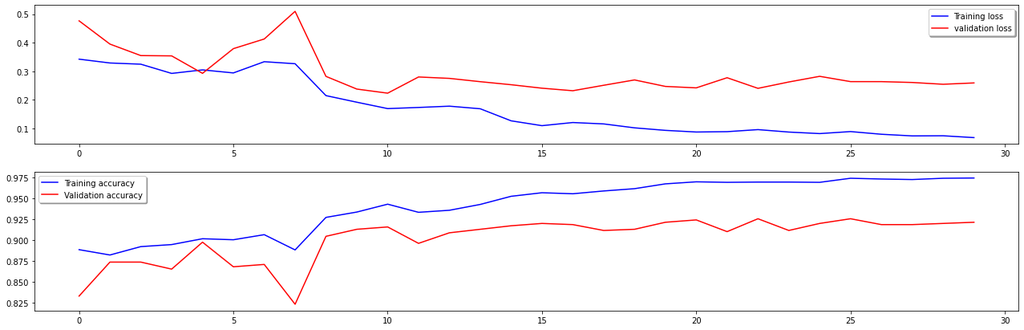

```python
fig, ax = plt.subplots(2,1 , figsize=(22,7))
ax[0].plot(history.history['loss'], color='b', label="Training loss")
ax[0].plot(history.history['val_loss'], color='r', label="validation loss",axes =ax[0])
legend = ax[0].legend(loc='best', shadow=True)

ax[1].plot(history.history['accuracy'], color='b', label="Training accuracy")
ax[1].plot(history.history['val_accuracy'], color='r',label="Validation accuracy")
legend = ax[1].legend(loc='best', shadow=True)
```

we can see the validation accuracy is going higher with reduction of the learning rate compared to original network.

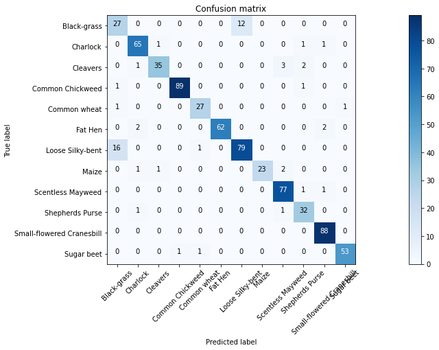

```python
from sklearn.metrics import confusion_matrix
import itertools
plt.subplots(figsize=(22,7)) #set the size of the plot

def plot_confusion_matrix(cm, classes,
                          normalize=False,
                          title='Confusion matrix',
                          cmap=plt.cm.Blues):
    """
    This function prints and plots the confusion matrix.
    Normalization can be applied by setting `normalize=True`.
    """
    plt.imshow(cm, interpolation='nearest', cmap=cmap)
    plt.title(title)
    plt.colorbar()
    tick_marks = np.arange(len(class_name))
    plt.xticks(tick_marks, class_name, rotation=45)
    plt.yticks(tick_marks, class_name)

    if normalize:
        cm = cm.astype('float') / cm.sum(axis=1)[:, np.newaxis]

    thresh = cm.max() / 2.
    for i, j in itertools.product(range(cm.shape[0]), range(cm.shape[1])):
        plt.text(j, i, cm[i, j],
                 horizontalalignment="center",
                 color="white" if cm[i, j] > thresh else "black")

    plt.tight_layout()
    plt.ylabel('True label')
    plt.xlabel('Predicted label')

# Predict the values from the validation dataset
Y_pred = model.predict(X_val)
# Convert predictions classes to one hot vectors
Y_pred_classes = np.argmax(Y_pred,axis = 1)
# Convert validation observations to one hot vectors
Y_true = np.argmax(y_val,axis = 1)
# compute the confusion matrix
confusion_mtx = confusion_matrix(Y_true, Y_pred_classes)
# plot the confusion matrix
plot_confusion_matrix(confusion_mtx, class_name)
```

with confusionmatrix we can understand which class is poorly classifed. we can see the classes loose silly and black-grass get the most error in classification and the improvement can be done in these two classes by feeding more data.

```python
class_name
```

```
array(['Black-grass', 'Charlock', 'Cleavers', 'Common Chickweed',
       'Common wheat', 'Fat Hen', 'Loose Silky-bent', 'Maize',
       'Scentless Mayweed', 'Shepherds Purse',
       'Small-flowered Cranesbill', 'Sugar beet'], dtype=object)
```

# 6. Visualize predictions for x_test[2], x_test[3], x_test[33], x_test[36], x_test[59]. (5 Marks)

```python
Predicted_classes = model.predict_classes(X_test)
```

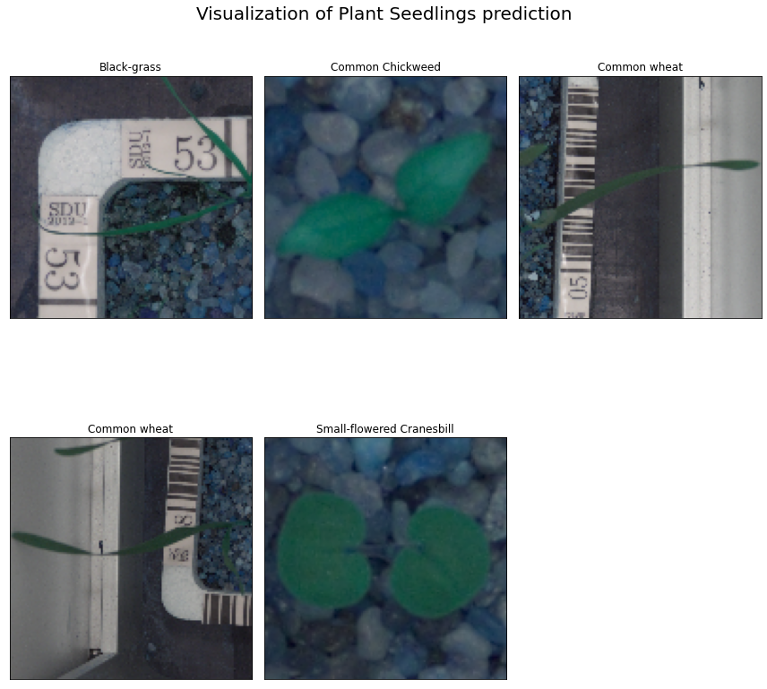

```python
plt.figure(figsize=(12,12))
k=1
for i in [2,3,33,36,59]:

    plt.subplot(2,3,k)

    plt.imshow(X_test[i])
    plt.title(class_name[Predicted_classes[i]])
    plt.xticks([]), plt.yticks([])
    k=k+1
plt.suptitle("Visualization of Plant Seedlings prediction", fontsize=20)
plt.tight_layout()
plt.show()
```

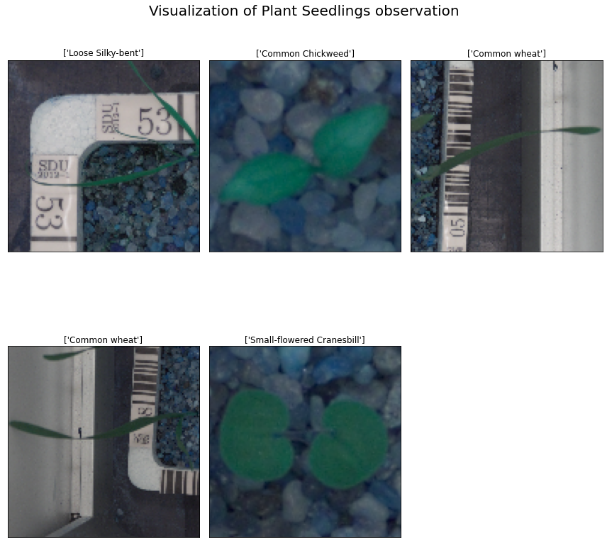

```python
plt.figure(figsize=(12,12))
k=1
for i in [2,3,33,36,59]:

    plt.subplot(2,3,k)

    plt.imshow(X_test[i])
    plt.title(class_name[y_test[i]==1])
    plt.xticks([]), plt.yticks([])
    k=k+1
plt.suptitle("Visualization of Plant Seedlings observation", fontsize=20)
plt.tight_layout()
plt.show()
```

All the classes are predicted correctly beside misclassification in first image.